# Coursework Template

MSc in Statistics 2026/27, Imperial College London

Author

Andrew Duncan, Oliver Ratmann

This Quarto document is intended to provide a basic template that you may use throughout the course, and to introduce you to basic functionality of the open-source bookdown R package for writing Rmarkdown documents (Xie 2016).

Please note this template uses:

- quarto/Rmarkdown syntax for the title and document style;
- *bookdown* syntax to label and reference equations;
- *bookdown* syntax to referencing literate and provide a bib file;
- *kable* syntax to build clean and clear tables that can be referenced;
- quarto/Rmarkdown inline functions to collect and print all code used.

See the examples below for how these are used.

# Sampling from the Cauchy distribution

In this question we seek to generate samples from the standard Cauchy distribution, with pdf given by
$$\begin{equation}
p(x) = \frac{1}{\pi (1 + x^2)}, \quad x \in \mathbb{R}.
(\#eq:1)
\end{equation}$$
The cdf associated with @ref(eq:1) is given by
$$\begin{equation}
F(x) = \frac{1}{\pi}\arctan(x) + \frac{1}{2}.
(\#eq:2)
\end{equation}$$

**Part a.** We apply the inversion method as described by Graham and Talay (2013). We first compute the generalised inverse of the cdf @ref(eq:2). To this end, let $y\in [0,1]$, then

$$\begin{align}
y &= F(x), \quad \iff (\#eq:3a) \\
y &= \frac{1}{\pi}\arctan(x) + \frac{1}{2} \quad \iff \\
y-\frac{1}{2} &= \frac{1}{\pi}\arctan(x) \quad \iff \\
\pi\left(y-\frac{1}{2}\right) &= \arctan(x) \quad \iff \\
x &= \tan\left(\pi\left(y-\frac{1}{2}\right)\right).
\end{align}$$

By the inversion method (Graham and Talay 2013), if $Y \sim U[0,1]$, then

$$\begin{equation}
X = \tan\left(\pi\left(Y-\frac{1}{2}\right)\right),
(\#eq:4)
\end{equation}$$

**Part b.** The empirical cdf based on $N$ samples $x_1, \ldots, x_N$ is defined to be
$$\widehat{F}(t) = \frac{1}{N}\sum_{i = 1}^N \mathbf{1}[x_i \leq t], \quad x\in \mathbb{t}.$$
To generate the empirical cdf in R, we perform the following steps:

1. Generate $N$ samples from the distribution using the inversion method, as detailed in the previous question.
2. Sort the samples in ascending order $x_1 \leq x_2 \leq x_3 \leq \ldots \leq x_N$.
3. The empirical CDF at value $x_i$ is given by $i/N$.

In the following figure we plot the empirical cdf based on 1000 samples (black line), and compare against the analytical cdf (red line).

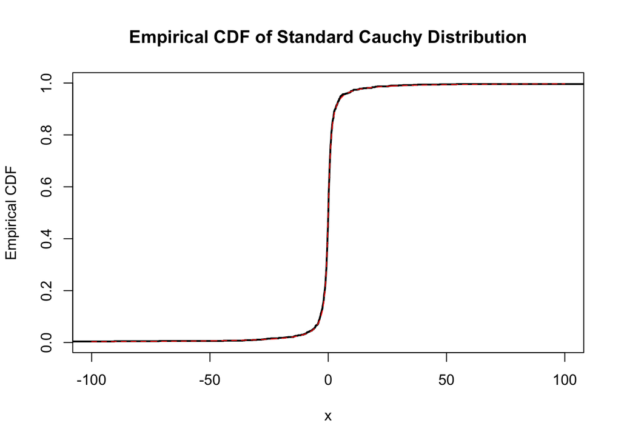

**Part c.** We shall use the samples to compute the empirical cdf for the values $x = 0.5, 1, 10$.

Empirical CDF

| x | ecdf |
| --- | --- |
| 0.5 | 0.65 |
| 1.0 | 0.76 |
| 10.0 | 0.97 |

# ChickWeight dataset analysis

We will explore some basic features of the ChickWeight dataset (Crowder and Hand 1990).

Let’s first see the number of chicks doing different diets.

Table 1: Number of chicks doing each diets.

| Diet | Count |
| --- | --- |
| 1 | 220 |
| 2 | 120 |
| 3 | 120 |
| 4 | 118 |

Table 1 shows that there are much more samples of chicks doing diet 1, which may cause bias in the later results.

Table 2: Linear model fitted with the chickweight dataset.

|  | MLE | Std. Err |
| --- | --- | --- |
| Intercept | 27.90 | 2.22 |
| Time | 8.72 | 0.18 |
| Chick L | 130.27 | 9.54 |
| Chick Q | -24.98 | 10.10 |
| Chick C | -16.29 | 10.42 |
| Chick 4 | 16.83 | 10.50 |
| Chick 5 | -11.89 | 10.42 |
| Chick 6 | 62.03 | 10.24 |
| Chick 7 | -5.78 | 10.06 |
| Chick 8 | -2.19 | 9.84 |
| Chick 9 | -2.57 | 9.57 |
| Chick 10 | -15.82 | 9.32 |
| Chick 11 | -29.29 | 9.10 |
| Chick 12 | 12.61 | 8.89 |
| Chick 13 | 45.57 | 8.73 |
| Chick 14 | 8.48 | 8.65 |
| Chick 15 | -36.79 | 8.59 |
| Chick 16 | -18.54 | 8.54 |
| Chick 17 | 13.82 | 8.51 |
| Chick 18 | 19.21 | 8.47 |
| Chick 19 | -15.11 | 8.40 |
| Chick 20 | 19.11 | 8.33 |
| Chick 21 | 10.39 | 8.30 |
| Chick 22 | -13.88 | 8.28 |
| Chick 23 | -2.61 | 8.22 |
| Chick 24 | 3.73 | 8.19 |
| Chick 25 | -30.74 | 8.21 |
| Chick 26 | 22.98 | 8.23 |
| Chick 27 | 37.25 | 8.20 |
| Chick 28 | 11.68 | 8.17 |
| Chick 29 | -15.85 | 8.19 |
| Chick 30 | -9.61 | 8.22 |
| Chick 31 | 2.65 | 8.23 |
| Chick 32 | 15.83 | 8.17 |
| Chick 33 | -4.21 | 8.18 |
| Chick 34 | -8.35 | 8.18 |
| Chick 35 | 0.68 | 8.16 |
| Chick 36 | -17.37 | 8.17 |
| Chick 37 | -2.60 | 8.17 |
| Chick 38 | -15.54 | 8.17 |
| Chick 39 | -2.81 | 8.24 |
| Chick 40 | -39.41 | 8.27 |
| Chick 41 | 15.49 | 8.25 |
| Chick 42 | -27.71 | 8.20 |
| Chick 43 | 32.33 | 8.17 |
| Chick 44 | -9.61 | 8.17 |
| Chick 45 | 12.81 | 8.17 |
| Chick 46 | -21.74 | 8.16 |
| Chick 47 | -6.34 | 8.20 |
| Chick 48 | -16.40 | 8.17 |
| Chick 49 | -25.39 | 8.16 |

Table 2 demonstrates the MLE and standard error of each features.

Maybe we can have a plot with weights as time varies.

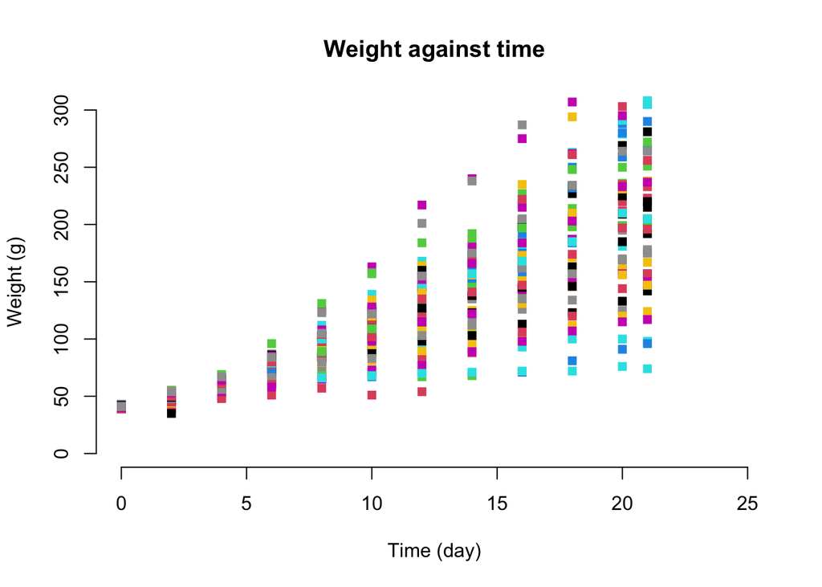

Figure 1: Weight against time by chicks.

Figure 1 shows some interesting results.

# Code appendix

Rather than re-paste all the code to the appendix, here is a trick which makes the markdown file output all the code (without) execution in the appendix, without any duplication.

Please keep in mind to format the code so that the entire code is clearly visible and does not run into the margins of the pdf version.

```r
knitr::opts_chunk$set(
  collapse = TRUE,
  comment = "#>"
)
include_solutions <- TRUE
library(rmarkdown)
library(knitr)
library(kableExtra)
library(magrittr)
# Put any library imports and other preamble here.

### Question 1a

generate_cauchy_samples <- function(n) {
  # Generate 'n' uniform random numbers between 0 and 1
  u <- runif(n)

  # Apply the inverse CDF formula to get Cauchy samples
  samples <- tan(pi * (u - 0.5))
  return(samples)
}

num_samples = 1000

# Generate samples from the standard Cauchy distribution
cauchy_samples <- generate_cauchy_samples(num_samples)


### Question 1b

# Sort the samples in ascending order
sorted_samples <- sort(cauchy_samples)

# Calculate the cumulative probabilities for each sample
cumulative_probs <- (1:num_samples) / num_samples

x_values <- seq(-100, 100,  length.out = 1000)
cdf_values <- pcauchy(x_values)

# Plot the empirical CDF
plot(sorted_samples,
     cumulative_probs,
     type = "s",
     xlab = "x",
     ylab = "Empirical CDF",
     main = "Empirical CDF of Standard Cauchy Distribution",
     lwd = 2, lty = 1, xlim = c(-100,100))
lines(x_values, cdf_values, type = "l",
      xlab = "x", ylab = "CDF", main = "CDF of Standard Cauchy Distribution",
      col = 'red', lty = 2)

### Question 1c

calculate_ecdf <- function(x) {
    return(sum(sorted_samples <= x)/num_samples)
}

df <- data.frame(x = c(0.5, 1.0, 10.0),
                ecdf = c(calculate_ecdf(0.5),
                         calculate_ecdf(1.0),
                         calculate_ecdf(10.0))
                )
kbl(df,
    caption = 'Empirical CDF',
    label = 'ecdf',
    digits = 2) %>%
  kable_styling(
    bootstrap_options = c("striped", "hover", "condensed"),
    font_size = 12)
cw <- ChickWeight
diet_counts <- table(cw$Diet)
knitr::kable(diet_counts, col.names = c("Diet", "Count"))
# fit linear model
weight_lm <- lm(weight ~ ., data = cw)

# extract coefficients and standard errors
weight_lm_coefficients <- summary(weight_lm)$coefficients[,1:2]

nice_names <- rownames(weight_lm_coefficients)

nice_names <- gsub("\\(Intercept\\)", "Intercept", nice_names)
nice_names <- gsub("\\.", " ", nice_names)
nice_names <- gsub("\\^", " ", nice_names)

rownames(weight_lm_coefficients) <- nice_names
knitr::kable(
  x = round(weight_lm_coefficients, 2),
  col.names = c("MLE", "Std. Err"))
plot(
  x = cw$Time,
  y = cw$weight,
  col = cw$Chick,
  pch = 15,
  xlim = c(0,25), # extend plotting area to make room for legend
  ylim = c(0,300),
  main = "Weight against time",
  xlab = "Time (day)",
  ylab = "Weight (g)",
  bty = "n")
```

## References

Crowder, Martin J., and David J. Hand. 1990. *Analysis of Repeated Measures*. Chapman & Hall.

Graham, Carl, and Denis Talay. 2013. *Stochastic Simulation and Monte Carlo Methods: Mathematical Foundations of Stochastic Simulation*. Vol. 68. Springer Science & Business Media.

Xie, Yihui. 2016. *Bookdown: Authoring Books and Technical Documents with r Markdown*. CRC Press.